# re_airquality

Lisa Raemy

2025-03-10

# Telling a story from data

## Libraries

```r
library(tidyr)
library(readr)
library(dplyr)
library(knitr)
library(ggplot2)
```

# Introduction

The goal of this analysis is to determine whether there is a positive correlation between temperature and ozone concentration and how this relationship varies from May to September in 1973.

It is expected, that higher temperatures positively correlate with higher ozone concentrations, because higher temperatures are often accompanied by stronger and faster photochemical reactions.

## Description of the airquality dataset

The ozone data “datasets::airquality” comes from the New York State Department of Conservation and the meteorological data from the National Weather Service.

The dataset shows air quality measurements in New York from May to September in 1973.

It contains 6 variables:  
Ozone [,1] = Ozone (ppb)  
Solar.R [,2] = Solar Radiation (lang)  
Wind [,3] = Wind (mph)  
Temp [,4] = Temperature (degrees F)  
Month [,5] = Month (1-12)  
Day [,6] = Day of month (1-31)

Information was found here:

```r
#looking at background information of the data
?airquality
```

# Data analysis

## Loading and cleaning data

Data is loaded and NA are removed.

```r
airquality <- datasets::airquality
airquality_clean <- na.omit(airquality)
```

## Statistical metrics

Several statistical parameters (min, 1st quantile, median, mean, 3rd quantile and max) are calculated and data is visualized to get a feel for the data and it’s distribution.

```r
# calculating statistical parameters
summary(airquality$Ozone)
```

```
##    Min. 1st Qu.  Median    Mean 3rd Qu.    Max.    NA's
##    1.00   18.00   31.50   42.13   63.25  168.00      37
```

```r
summary(airquality$Temp)
```

```
##    Min. 1st Qu.  Median    Mean 3rd Qu.    Max.
##   56.00   72.00   79.00   77.88   85.00   97.00
```

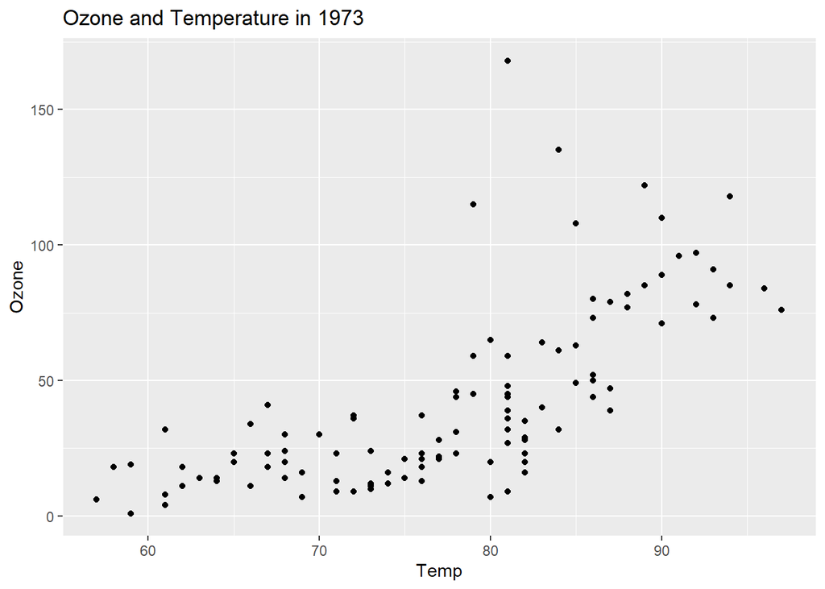

```r
# plotting data to get a feeling for it's distribution
ggplot(data = airquality_clean,
      aes(x=Temp,
          y=Ozone)) +
      labs(title = "Ozone and Temperature in 1973") +
      geom_point()
```

## Correlation between temperature and ozone

To answer the research question the overall correlation between temperature and ozone is calculated.

```r
# calculating correlation between temperature and ozone with pearson-correlation
corr_test <- airquality_clean |>
  with(cor.test(Temp, Ozone))

# showing only correlation and p_value
corr_summary <- tibble(
  correlation = corr_test$estimate,
  p_value = corr_test$p.value)
corr_summary
```

```
## # A tibble: 1 × 2
##   correlation  p_value
##         <dbl>    <dbl>
## 1       0.699 1.55e-17
```

## Calculating regression between ozone and temperature

A linear regression model is performed, looking at ozone and temperature.

```r
# making linear regression model
regression_airquality_clean <- airquality_clean |>
  lm(Ozone~Temp, data = _) # data=_, takes the data that comes out

# showing results of the linear regression model
summary(regression_airquality_clean)
```

```
##
## Call:
## lm(formula = Ozone ~ Temp, data = airquality_clean)
##
## Residuals:
##     Min      1Q  Median      3Q     Max
## -40.922 -17.459  -0.874  10.444 118.078
##
## Coefficients:
##              Estimate Std. Error t value Pr(>|t|)
## (Intercept) -147.6461    18.7553  -7.872 2.76e-12 ***
## Temp           2.4391     0.2393  10.192  < 2e-16 ***
## ---
## Signif. codes:  0 '***' 0.001 '**' 0.01 '*' 0.05 '.' 0.1 ' ' 1
##
## Residual standard error: 23.92 on 109 degrees of freedom
## Multiple R-squared:  0.488,  Adjusted R-squared:  0.4833
## F-statistic: 103.9 on 1 and 109 DF,  p-value: < 2.2e-16
```

## Making a scatterplot with regressionline

To visualize the linear regression between ozone and temperature a scatterplot is made.

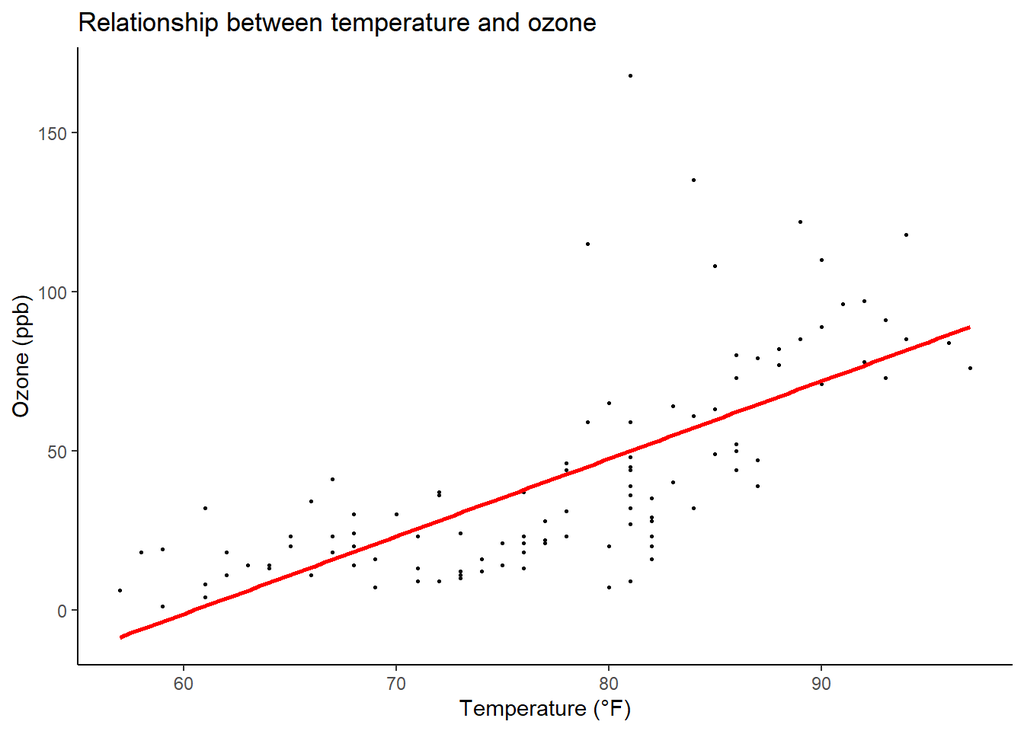

```r
# scatterplot showing linear regression between ozone and temperature
airquality_clean |>
  ggplot(
  aes(x=Temp, y=Ozone)) +
  geom_point(size=0.5) +
  geom_smooth(method="lm", color = "red", se=FALSE) +
  labs(title="Relationship between temperature and ozone",
       x="Temperature (°F)",
       y="Ozone (ppb)") +
  theme_classic()
```

## Correlation between ozone and temperature over the months

Now that a positive correlation between ozone and temperature was found, this relationship and its variation over the months of May to September is being analyzed.

First the mean temperature and mean ozone for every month is calculated to get a feel for the data.

```r
# calculating mean temp and mean ozone for every month
mean_monthly_airquality <- airquality_clean |>
  dplyr::group_by(Month) |>
  dplyr::summarize(mean_temp = mean(Temp),
                  mean_ozone = mean(Ozone))
```

Then the correlation between ozone and temperature is calculated for every month. Changes in the relationship between ozone and temperature over the months are being analyzed.

```r
# calculating the correlation for every month
monthly_corr_test <- airquality_clean |>
  dplyr::group_by(Month) |>
  dplyr::summarize(correlation= cor(Temp, Ozone),
         p_value = cor.test(Temp, Ozone)$p.value)

# making one data frame --> joining the means in mean_monthly_airquality and the monthly correlation in monthly_corr_test
monthly_summary <- left_join(mean_monthly_airquality, monthly_corr_test, by="Month")
```

## Linear regression between ozone and temperature over the months

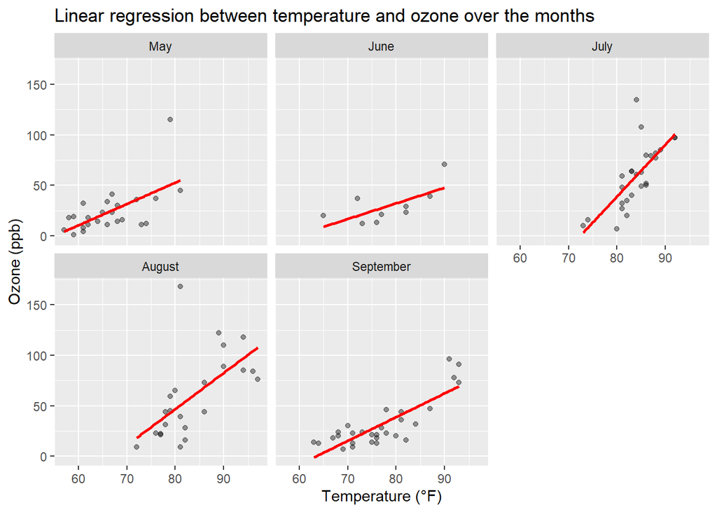

```r
# make a new factor variable with the names of the months, the numbers in the data stay
airquality_clean <- airquality_clean|>
  mutate(Month_label = factor(Month,
                              levels = 5:9,
                              labels = c("May", "June", "July", "August", "September")))

# plotting the data
# plot that shows linear regression between temperature and ozone over the months
ggplot(
  data=airquality_clean,
  aes(x = Temp, y = Ozone)) +
  geom_point(alpha = 0.4) +
  geom_smooth(method = "lm", color= "red", se=FALSE) +
  labs(title = "Linear regression between temperature and ozone over the months",
       x = "Temperature (°F)",
       y = "Ozone (ppb)") +
  facet_wrap(~Month_label)
```

## Checking variations in ozone concentration over time

A box plot that shows the distribution of ozone concentration over time is made.

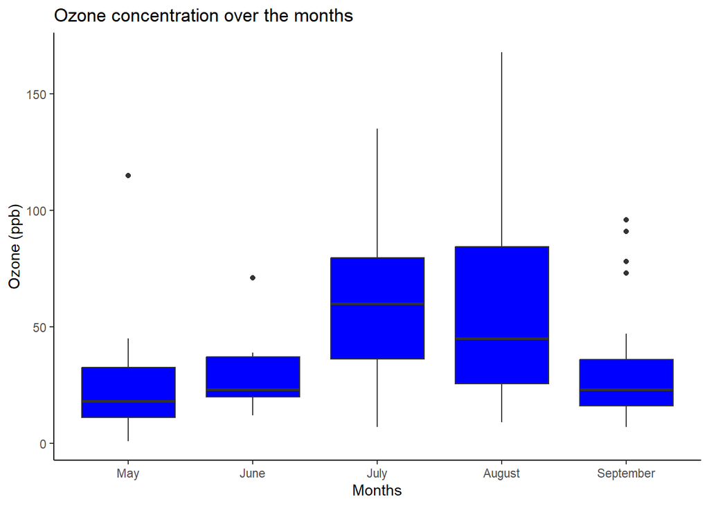

```r
# making a boxplot that shows the distribution of the ozone concentration over time
airquality_clean |>
  ggplot(
  aes(x = Month_label, y = Ozone)) +
  geom_boxplot(fill = "blue") +
  labs(title = "Ozone concentration over the months",
       x = "Months",
       y = "Ozone (ppb)") +
  theme_classic()
```

# Key findings and discussion

A statistically significant positive correlation between temperature and ozone concentration could be confirmed.

The linear regression model describes the relationship between ozone concentration and temperature in more detail. It indicates that for every 1° F increase in temperature the ozone concentration increases approximately by 2.44 ppb. The multiple R-squared shows that approximately 48.8% of the ozone variability can be explained through temperature. The remaining 51.2% can be explained by other factors that are not included in this model.

The linear regression analysis across months shows that July and August have the steepest slopes, meaning that changes in temperature strongly influence the ozone concentration during these months. Flatter slopes (May, June and September) show a weaker temperature-ozone relationship. The weaker relationship during May and June may be due to weaker solar radiation during these months. In September we have decreasing temperatures which could lead to this weaker relationship. There are also a number of outliers that could influence the steepness of the slope.

The boxplot analysis of ozone concentration over time shows that the ozone concentration peaks in July and then decreases until September. July and August have the highest median ozone levels and also the widest interquartile ranges, which indicates a high variability in ozone levels. May, June and September have smaller interquartile ranges, which means ozone levels are more stable. This variability could be due to changing weather conditions during summer. September has the highest number of outliers in ozone concentration.